# A3: SPL Library Checkouts

### Introduction

For this assignment, I am working on a data set provided by the Seattle public library. The data set contains information of items that had been checked out for more than ten times in a month from January 2017 to January 2023. We could look at the publisher, material type and a lot of other characteristics of the items. To look more in detailed, I picked three topics to look closer in the data set.

The first topic is about the general form of checked out items. There are only two possibilities: “physical” or “digital”. The presence of the pandemic had changed our life styles significantly and I am interested in whether it had an impact on what kind of items people choose to check out.

My second interest is about the two series of fictions that I enjoyed reading as a teenager. The data was filtered out by author to avoid missing out books with irregular titles in the series. One author is J. K. Rowling, the author of the world-wide popular series *Harry Potter*. The other author is the author of the *Warriors* series, Erin Hunter. It is not as famous as the *Harry Potter* series and I am curious about whether the series had became more popular in the past few years.

The third chart will be about the total checkouts in different forms of materials. There are a lot of material types including books, eBooks, video discs, etc. It is interesting to look into what types of items people prefer to check out nowadays. Therefore, I created a plot to see the percentage of each material type’s checkout in the past six years.

### Summary Information

To have a general understanding of what the data set has, we should look at a few summary data extracted from the data set. There are 32 categories of materials that had been check out. A few categories in the chart are the combination of multiple materials, but the number of categories is still surprisingly high. Among these materials, the highest one had a total of 6397967 checkouts. This is the cumulative number for one material over the past 6 years. We will look into the number for other materials more in detailed in chart 3. The highest number of checkouts of a single item in one month is4903. The year with the most total checkouts in 2017-2023 is 2019. Lastly, I calculated the total number of checkouts in digital and physical form to see which form was more used. And the answer is physical with the number of 10166737.

### The Dataset

This dataset was provided by the Seattle Public library. There are originally 12 parameters of the data: usage type (digital or physical), checkout type, material type, year of checkout, month of checkout, number of checkout in that month, the title, the isbn, the creator, the subject, the publisher, and the publication year. The data was collected by the library since 2005 and this subset I used only contains the data of books with more than 10 checkouts per month from January 2017 to January 2023. Recording checkouts is a necessary step in libraries. Seattle Public Library decided to collect and cleaned these information for people that are interested in the topic. Since the data does not include any personal information of the people that checked the book out, there is not an ethical question for me to consider. The limitation is that the data set only contains books with more than 10 checkouts per month. If someone wants to know more about what books people are interested in, there might be a lot of books that will not be counted with this data set. Also, since an item could have mulitiple subjects, it is hard to look into question about subjects. It is really hard to break the subjects down into separate columns.

### Chart 1: Total Checkouts in Digital and Physical Form

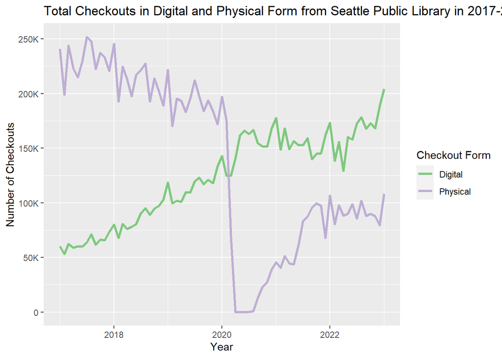

As shown in the graph, the purple line represents the total number of checkouts in physical form and the green line. I am interested to the comparison of checkouts between the two forms. In my opinion, reading from papers feel completely different with reading from electronic devices. I prefer to read from paperback books, but reading from screens is a lot more easier and more convenient. Therefore the first chart is to see which form is more picked by the customers of the Seattle Public Library.

Physical items were checked out much more often than digital items until the spring of 2020. It was the start of the pandemic and how people live changed significantly since then. More people work remotely and the offline activities declined. Therefore the checkouts in physical form also dropped significantly. From around March to July of 2020, the number of checkouts were so little that we could hardly see it moves away from the x axis. Although the number slowly grows up since the latter half of 2020, it never went back to how it used to be.

On the other hand, the number of digital checkouts kept growing in the past six years. Although there were some declines, the overall tendency is to increase. I think this was caused by the development of technology. Nowadays people could access more and more things in digital form, which might caused the increase in the number of digital checkouts in the Seattle Public Library. Since the line for digital checkouts is overall growing through the time span, it hard to say the influence of the pandemic to the digital checkouts.

### Chart 2: Total Checkouts of Books from Erin Hunter and J. K. Rowling

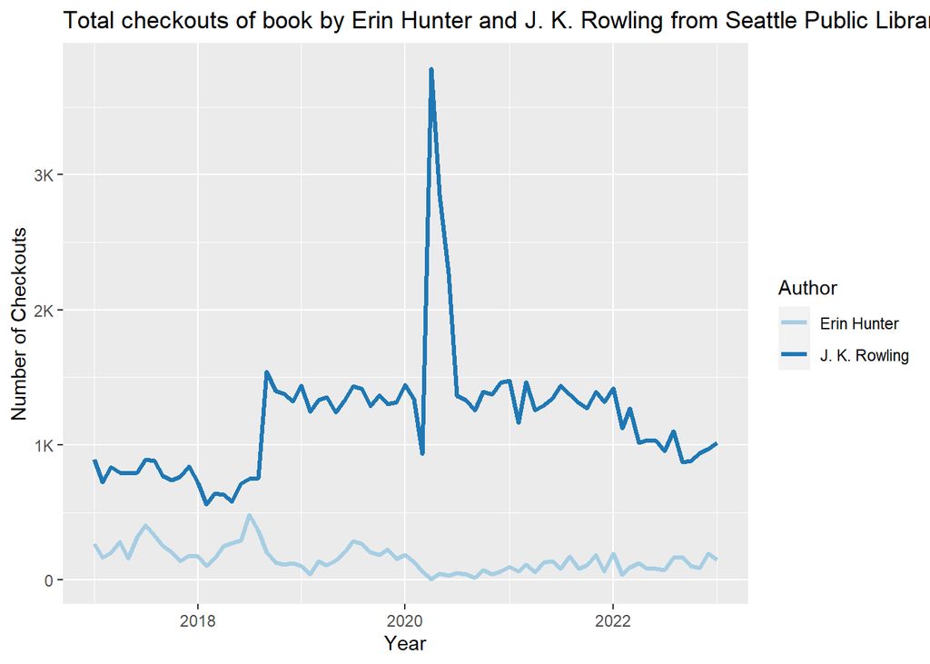

This chart shows the total checkouts of books from J. K. Rowling and Erin Hunter by month in 2017-2023. They represent the two series of books I enjoyed as a teenager. J. K. Rowling wrote the very famous *Harry Potter* series and Erin Hunter created the fantasy world of the *Warriors*.

The brand of *Harry Potter* had a lot of related news and works every year. J. K. Rowling also had some controversial news about her opinions in other topics. These factors might influence how people think about *Harry Potter* and the number of checkouts of works in the series. Therefore I picked J. K. Rowling as one of the two authors I want to look about.

The *Warriors*, on the other hand, is purely my personal interest. It was my favorite series of books as an elementary schools student and a teenager. I did not put as much attention to the new books in the series as I grew older and became more busy. However, I am still interested in the series and want to know if it has became more known than before. So Erin Hunter is my other pick for this chart.

To create the plot, I filtered the data frame by author and combined the checkouts of all books from the same author together. I did not choose to filter by the title since some of the books in the series do not have the same keyword as the other books. Although there are also relevant books in the series that were written by other people, checkouts of these books are not counted.

### Chart 3: Total Checkouts by Material Type

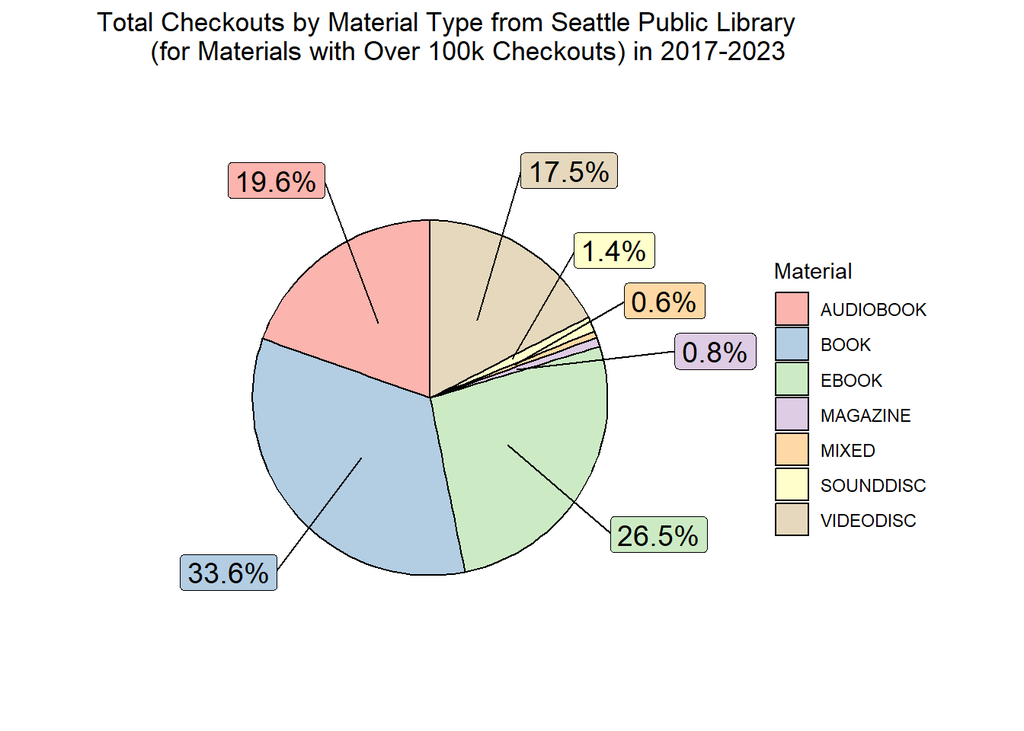

For the third graph, I created a pie chart based on the total checkouts by material type. As I mentioned in the summary section, there are a total of 32 types of materials. It is too much to include if we put them all in one pie chart. After looking at the numbers, I decided to only keep the materials with more than cumulative 100000 checkouts in 2017-2023. That cuts the number down to 7 materials.

The top three materials, book, eBook and audio book are all different forms to read published works. It proves that although we have more options to spend our spare time, reading books is still one of the top choices. As more people choose to do things remotely, I am very curious about how this pie chart might change in a few years. Maybe next year, the percentage will be significantly different.